# Food at College

```r
# From your file menu (at the top of R-Studio) select:
# "Session -> Set working directory -> To source file location"
# Then play this chunk to get the data into R.
library(mosaic)
library(car)
library(DT)
library(pander)
library(readr)
library(tidyverse)


food <- read_csv("../../Data/food.csv")   #food.csv is in the Data folder...
colnames(food)[19] <- "eating_out"

food$weight <- as.numeric(food$weight)
food <- food |> filter(!is.na(weight))
view(food)
```

## Background

We are trying to see if there is a correlation between the frequency of eating out and the peoples weight. Using a kruskal test will help us find that out. Its easier to then find out how multiple categorical factors impact a numeric response variable.

### Hypotheses

We are trying to prove that peoples weight come from different distribution and the frequency of eating out has an impact on weight.

$$H_0: \text{All the weights come from the same distribution regardless
of how frequent they eat out.}$$

$$H_a: \text{At least one distribution is stochastically different than
the others.}$$

$$\alpha = 0.05$$
—-

## Test

```r
kruskal.test(weight~ eating_out,data = food)
```

```
##
##  Kruskal-Wallis rank sum test
##
## data:  weight by eating_out
## Kruskal-Wallis chi-squared = 5.0817, df = 4, p-value = 0.279
```

The above test fails to reject the null hypothesis because the P-value is way above our alpha and this is a clear indicator that frequency of eating out has no significant impact on weight.

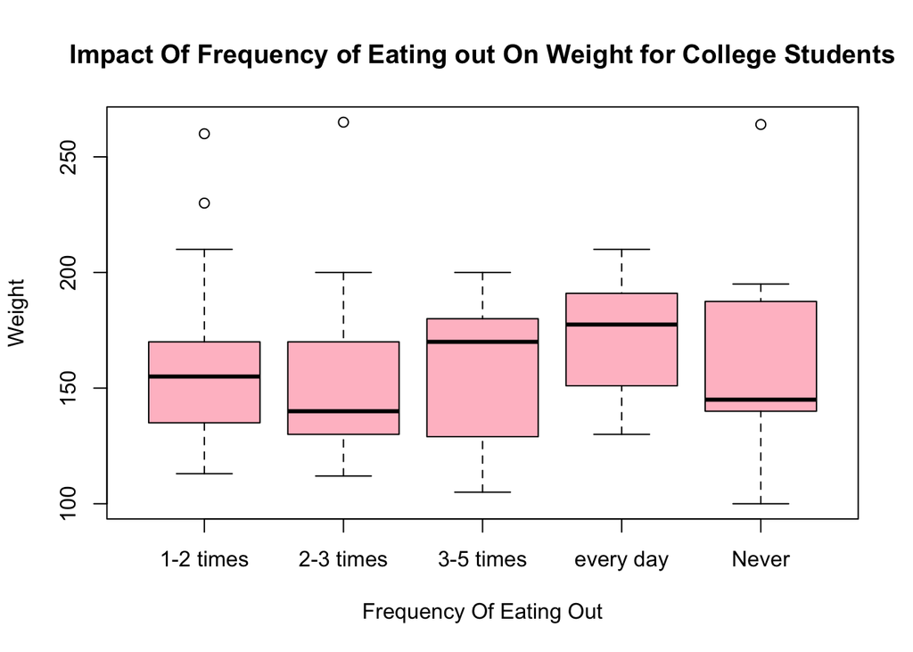

```r
boxplot(weight ~ eating_out, data=food, col='pink', ylab="Weight", main="Impact Of Frequency of Eating out On Weight for College Students", xlab="Frequency Of Eating Out")
```

## Implication of Box Plot

There seems to be very little to no difference overall peoples weight but the means look a bit different. The means on the box plot seem to fluctuate when you move from one box plot to the other with a standard deviation of between 25 lbs and 40 lbs

## Numerical Summary.

```r
favstats(weight ~ eating_out, data=food)[,-10] %>%
  pander(caption="Peoples weight in Relation How often they eat out")
```

Peoples weight in Relation How often they eat out

| eating_out | min | Q1 | median | Q3 | max | mean | sd | n |
| --- | --- | --- | --- | --- | --- | --- | --- | --- |
| 1-2 times | 113 | 135 | 155 | 170 | 260 | 157.6 | 29.23 | 58 |
| 2-3 times | 112 | 131.2 | 140 | 168.8 | 265 | 153 | 35.79 | 22 |
| 3-5 times | 105 | 129 | 170 | 180 | 200 | 157.5 | 29.33 | 13 |
| every day | 130 | 159 | 177.5 | 190.5 | 210 | 172.4 | 26.5 | 12 |
| Never | 100 | 140 | 145 | 187.5 | 264 | 159.9 | 40.79 | 15 |

### Numerical Summary Explanation

The last column shows the sample size and we can see that the group of people that eat everyday were fewer than those that ate 1-2 times a week. The Median weight is highest for those that eat out everyday.

## Test for Normality.

```r
par(mfrow=c(1,1))

# Perform ANOVA
food.aov<- aov(weight ~ eating_out, data = food)

# Print the ANOVA table
#print(summary(result)) |> pander()
```

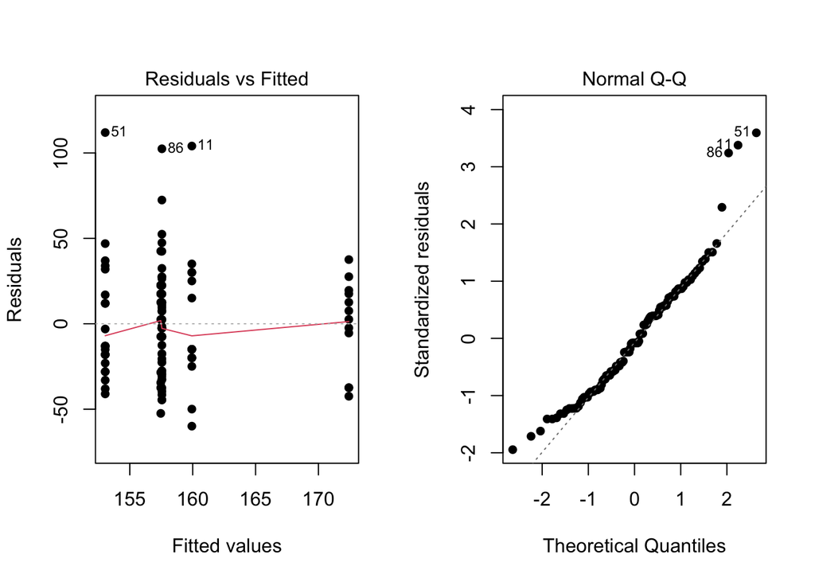

```r
par(mfrow=c(1,2))
plot(food.aov, which=1:2, pch=16)
```

### QQPLOT Explanation

From the above informatoion we can see that there is an issue of normality when it comes to the data set. Since a kruskal test is not the most reliable when it comes to checking for normality I used the Anova test and then used the results to plot a QQplot and got the result about the normality. Points 86,11 and 51 are out of range on the normal plot but when you check the residuals thats where you can see that the data is not normal at all. The Kruskal Wallis Test is the best option when it comes to using data that has normality issues.

## Conclusion

Conclusively we see that there is no link between eating out often and the amount of bosy weight that a person will have. First the P value is totally above our alpha so that kind of throws off our assumption so we have to fail to reject the null hypothesis.